# SimpleLink Gen1 to Gen2 SDK Migration Guide

## Table of Contents

### Appendicies

- Appendix I. Reference porting code
  - Appendix I-1. Simplelink API porting code (sl_compat.h)
  - Appendix I-2. OS API porting code
    - Appendix I-2.1 OS adaption header (osi.h)
    - Appendix I-2.2 OS adaption source (os_posix.c)

### List of Figures

- Fig. 1: Top level SDK structure
- Fig. 2: Top level folder structure
- Fig. 3: Examples folder structure

### List of Tables

- Table 1: Host driver API changes

# 1. Introduction

CC31xx SimpleLink Wi-Fi Network Processor and CC32xx SimpleLink Wi-Fi Wireless MCU are the second generation devices in the SimpleLink Wi-Fi and Internet-of-Things family. These devices introduce some new features and capabilities that further simplify the connectivity of things to the internet.

**Among the new capabilities are:**

- AP supporting up to 4 stations
- Improved provisioning
- Improved power consumption
- Increased number of secure sockets with a new ability to upgrade TCP socket to secure during connection
- IPv6 addressing scheme
- Return to factory defaults or Factory image
- Bundle protection to allow keeping the system integrity during OTA
- Security aspects:
  - Secure file system
  - Cloning protection
  - Software tamper detection
  - Trusted root certificate catalog for authentication
  - Access control using tokens
  - Other utilities such as secure content delivery

This document intends to guide users who already have experience with the CC3100/CC3200 devices and need to port their software to the new CC31xx/CC32xx family of devices. The document describes the new SDK structure and highlights the software components that require attention including host driver, OS layers, board drivers, and external libraries.

# 2. SDK Structure

## 2.1 Overview

The new SDK structure for CC31xx/CC32xx intends to create a common software development platform across all TI chipsets. Its main target is to emphasize the ease of use and specifically highlight:

- New folder structure which is easy to access and follow through
- Same look and feel for all documents and modules
- Simple migration between TI MCUs
- Simple migration between operating systems

## 2.2 High level view of SDK

Figure 1 illustrates the top level SDK structure. The SDK software abstracts the specific hardware (in this case, CC31xx/CC32xx) to the application.

The main target of the hardware abstraction layer is to simplify access to device modules. Each device or family of devices implements its device-specific implementation. In the previous SDK, this was also known as the driverlib module.

The RTOS layer implements the operating system. The SDK includes implementations for SYS/BIOS (TI-RTOS) and FreeRTOS. In case a different OS is desired, its implementation goes under the RTOS block. POSIX layer is used for OS abstraction. If a new OS is implemented, it needs to fit the POSIX layer. DPL (Driver Porting Layer) is used by the Drivers layer whenever OS services are required. The DPL abstracts the drivers similarly to how the POSIX layer abstracts the RTOS kernel functionality used by the application.

The Drivers layer is platform-independent. This layer bridges between the platform-dependent HAL layer and the application layer. This layer is common to all TI family of devices. In case OS services are required, the Drivers layer uses the DPL block.

The Middleware layer implements common libraries that may be used by the application. These components add additional functionality on top of the hardware-specific drivers. Examples of such common libraries include the graphic grlib, file system fatfs, and so forth.

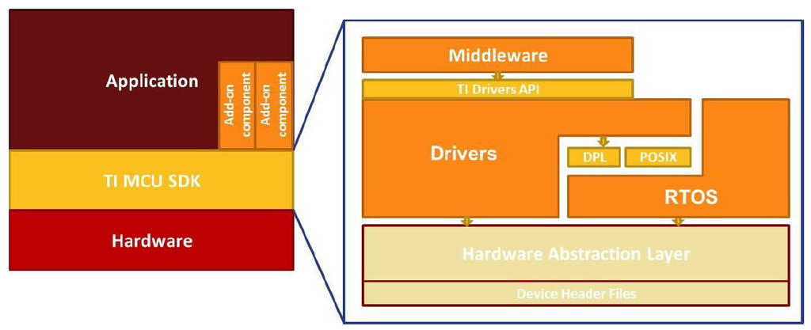

**Fig. 1: Top level SDK structure**

## 2.3 Top level folder structure

Figure 2 illustrates the top level folder structure. The OS directory includes SYS/BIOS (TIRTOS) implementation as well as FreeRTOS implementation. The `source` directory includes the `third_party` directory for middleware implementation and `ti` directory mainly for Drivers (`/source/ti/drivers` directory) and HAL layers (`/source/ti/devices/cc32xx/driverlib` directory). It also includes the `net` directory for external libraries. Additional libraries may be added in future releases. For reference, the Wi-Fi host driver is located as one of the many drivers under `/source/ti/drivers/net/wifi` directory. The `examples` directory is detailed in section 2.4.

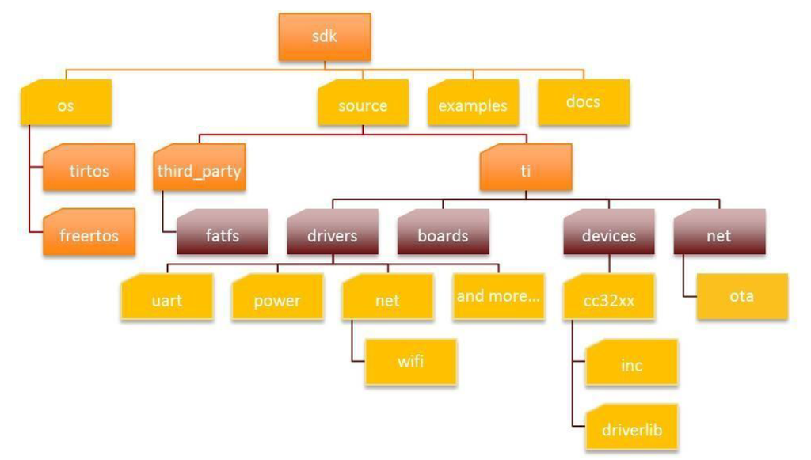

**Fig. 2: Top level folder structure**

## 2.4 Examples folder structure

Figure 3 illustrates the `examples` folder structure. Every board flavor has a corresponding directory. As illustrated, CC32xxS and CC32xxSF implementations for the CC32xx secured and CC32xx secured flash devices are included. Each board has a `sysbios` directory for TI-RTOS examples, `drivers` directory for drivers examples, and `demos` directory for a few full demos examples.

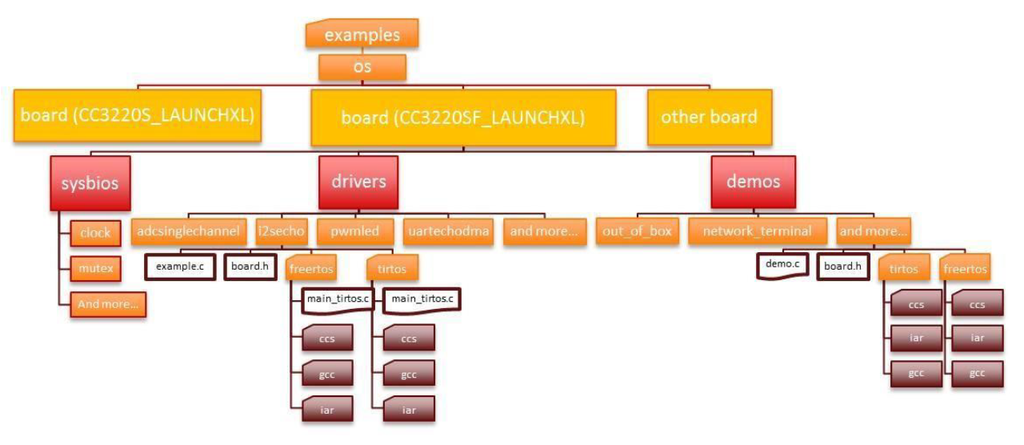

**Fig. 3: Examples folder structure**

# 3. Host Driver

## 3.1 Overview

The new host driver adds support for the new features and capabilities. Most of the APIs remain similar but not all of them are identical to those used in the CC3100/CC3200 host driver. The changes include modifications to function parameters (type, meaning or values), return codes and types, and new naming conventions.

Additionally, there are a few changes in device behavior or defaults that also require attention when moving to CC31xx/CC32xx devices.

## 3.2 SimpleLink device behavior and defaults changes

The following list outlines key changes to CC31xx/CC32xx SimpleLink devices that require attention. *CC3100/CC3200 devices* are marked as *R1* denoting *1st generation devices* while **CC31xx/CC32xx devices** are marked as **R2** denoting **2nd generation devices**:

- Device Default
  - Wi-Fi Mode
    - *R1: STA*
    - **R2: AP**
  - Regulatory Domain
    - *R1: US (channels 1-11)*
    - **R2: EU (channels 1-13)**
- Security related
  - Behavior while the SFLASH is empty:
    - *R1: Start to run with some default settings*
    - **R2: Device enters into a “lock” state and waits to be programmed. In this state, all APIs are blocked excluding those APIs intended for programming the device or return to factory image or default**
  - SFLASH Corruption
    - *R1: No clear indication, system behavior is not predicted*
    - **R2: System is locked. The host gets an event that allows it to be able only to reprogram the system or try to return to factory image**
  - Certificate files
    - *R1: Certificates were located under /sys/cert/. Only der format supported*
    - **R2: Certificates could be stored anywhere. Both der and pem formats supported. Enterprise certificates still need to be stored under predefined locations:**
      - `/sys/cert/ca.pem`
      - `/sys/cert/client.pem`
      - `/sys/cert/private.key`
- HTTP Web Server
  - *R1: HTML format*
  - **R2: Improved web pages based on rest APIs**
- IPv6
  - *R1: Not supported*
  - **R2: IPv6 supported, disabled by default**
    - **Supported only in STA mode**
    - **In host driver under `user.h` header file, ensure to `#define SL_SUPPORT_IPV6**`
    - **Enable at least local address (global is optional). See netcfg.h header file for more details**

      ```c
      IfBitmap = SL_NETCFG_IF_IPV6_STA_LOCAL | SL_NETCFG_IF_IPV6_STA_GLOBAL;
      sl_NetCfgSet(SL_NETCFG_IF,SL_NEFCFG_IF_STATE,sizeof(IfBitmap),&IfBitmap);
      ```

- File System
  - *R1: Support up to 100 user files*
  - **R2: Support up to 180 user files**
- CC3100 ForceAP GPIO (GPIO13):
  - *R1: Force the system to wake-up in AP mode regardless other settings*
  - **R2: Removed**
- Trusted root-certificate catalog:
  - *R1: NA*
  - **R2: All certificate authorities should reside in the list of valid CAs as part of the certificate catalog file. Some of the file system security options require the CA to be part of the list otherwise it might be interpreted as a security alert. Secure sockets could be used without it but consequently, a warning might be sent to the Host. The Image Creator installs the certificate catalog by default.**
- IPv4 Addressing
  - LLA
    - *R1: When DHCP client is enabled and there is no DHCP server available, the device does not have a valid IPv4 address so it is not able to use the network*
    - **R2: On timeout of trying to acquire an IPv4 address from a DHCP server, the system self-acquires an IP address using LLA protocol. This IP is limited to be used in a local network only. The host should be aware of this possibility.**
  - Default IP settings in AP mode:
    - *R1: 192.168.1.1*
    - **R2: 10.123.45.1**
- API Errors codes
  - *R1: Each function implements its own error codes. Same error codes could repeat in different functions*
  - **R2: Unique errors per function. All error definition available in a new header file**

## 3.3 API changes

API modifications are required when porting a working application from CC3100/CC3200 to CC31xx/CC32xx. The type of change is either an API addition, API removal, API change, parameters extension or return value change. It can also be a combination of changes. New naming conventions for functions and variables are also used in order to align with unified coding conventions across all product families. Table 1 lists all API changes.

**Table 1: Host Driver API changes**

[output not shown]

> **NOTE:** To reduce the initial porting effort, you may refer to the sample code provided below (see Appendix I-1. Simplelink API porting code) that converts the old CC3x00 API to the updated CC3x20 interface (it mostly includes the updates as defined by the table above).  
> For future compatibility, it is recommended to update the original application code so it directly uses the latest Simplelink API. Although the provided code can be used as is, it should be referred as an example for the required code adaptation.  
> Note also that the code covers most of the API changes, but not all of them. Some of the changes would still cause compilation errors and would need to be handled manually. The sample code only covers backward compatibility. There are new features and parameter values in the new release that must be handled specifically by the application (examples of usage can be found in the CC3x20 SDK demo code).

## 3.4 Miscellaneous

In additional to the changes above, the following additional changes were made to the new host driver:

- `netutil.c`: new module providing network utilities such as secure content delivery.
- `errors.h`: new header file added to concentrate all errors types in the driver.
- `user.h`: the following optional async event user’s callbacks were added:
  - `slcb_GetTimestamp`: enables the host driver to detect timeouts and errors during its communication with the network processor.
  - `slcb_NetAppRequestHdlr`: enables the application to respond to resource requests by the network processor during HTTP requests.
  - `slcb_NetAppRequestMemFree`: enables the host driver to free resources which were dynamically allocated by the application. If not implemented, static allocation is assumed.
  - `slcb_DeviceFatalErrorEvtHdlr`: enables the application to receive fatal error events which occur in the network processor or host driver, and require device restart. In previous version, these kinds of events have been notified by the `slcb_DeviceGeneralEvtHdlr` callback.

# 4. Operating system

## 4.1 Overview

The SDK for CC3100/C3200 included an `osi.h` header file which declared all the supported OS-related utilities as well as `osi_tirtos.c` and `osi_freertos.c` for specific SYS/BIOS (TIRTOS) and FreeRTOS implementations.

POSIX implementation for FreeRTOS is located under: `/os/freertos/posix`

POSIX implementation for SYS/BIOS (TI-RTOS) is located under: `/os/tirtos/packages/ti/sysbios/posix`

> **NOTE:** To reduce the initial porting effort, you may refer to the abstraction code provided here (see Appendix I-2. OS API porting code) that converts the obsolete OSI interface to POSIX calls. For future compatibility (and to eliminate redundant code), it is recommended to update the original application code so it directly uses the POSIX API. Although the provided code can be used as is, it should be referred as an example for the required code adaptation.

The following paragraphs describe the typical configuration of all OS-related elements using the POSIX APIs. Browse the POSIX documentation in case a special OS configuration is desired.

## 4.2 Threads

Thread creation is composed of a two-step procedure: setting the thread attributes and creating the thread. Thread attributes are configured using the `pthread_attr` APIs. Thread creation is configured using the `pthread` APIs.

```c
int pthread_attr_init(pthread_attr_t *attr);
int pthread_attr_destroy(pthread_attr_t *attr);
```

`pthread_attr_init()` initializes the `pthread_attr_t` object pointed to by `attr` with default values. The stack size is initialized to `Task_defaultStackSize` and the priority to `1`. The other `pthread_attr_` functions can be used to change the defaults.

`pthread_attr_destroy()` destroys the `pthread_attr_t` object pointed to by `attr`.

```c
int pthread_attr_setstacksize(pthread_attr_t *attr, size_t stacksize);
```

```c
int pthread_attr_setschedparam(pthread_attr_t *attr, const struct sched_param *schedparam);
```

To create a thread, `pthread_create()` needs to be used.

```c
int pthread_create(pthread_t *newthread, const pthread_attr_t *attr, void * (*startroutine)(void *), void *arg);
```

This function starts a new thread running the `startroutine` function, with the parameter arg passed to `startroutine`. If attr is `NULL`, the thread is created with default `pthread` attributes.

## 4.3 Semaphores

The following semaphore APIs are supported:

```c
int sem_destroy(sem_t *sem);
int sem_getvalue(sem_t *sem, int *value);
int sem_init(sem_t *sem, int pshared, unsigned value);
int sem_post(sem_t *sem);
int sem_timedwait(sem_t *sem, const struct timespec *abstime);
int sem_trywait(sem_t *sem);
int sem_wait(sem_t *sem);
```

`sem_wait()` waits forever on a semaphore where as `sem_timedwait()` waits for a specific timeout. `sem_timedwait()` API blocks only until the specified time has been reached or the semaphore becomes available, whichever happens first. Note that the time passed to the API is an absolute time, not a relative timeout. The timespec structure is defined in `types.h`:

```c
struct timespec {
    time_t tv_sec; /* Seconds */
    long tv_nsec; /* Nanoseconds */
};
```

To fill in the `timespec` object, `clock_gettime()` API needs to be used first.

```c
clock_gettime(0, &abstime);
```

Add the relative timeout value to `abstime`. For example:

```c
abstime.tv_sec++; /* A one second timeout */
```

*- or -*

```c
abstime.tv_nsec = 1000000; /* A one msec timeout */
```